# Examen parcial 3

Jorge Gómez

5/21/2021

# Primer ejercicio:

1. Genera un programa en R que a partir de los siguientes datos calcule para cada ecosistema (eco1,eco2,eco3) : la riqueza , diversidad alfa con al menos tres subíndices, diversidad beta con al menos un índice (https://stat.ethz.ch/R-manual/R-devel/library/base/html/sets.html) y una gŕafica de la abundancia ordenada de mayor a menor. No puedes usar librerías especializadas en ningún caso.

Las siguientes líneas hacen objetos con el número de especies que se van a usar y los rangos en la abundancia que pueden estar cada una de las especies.

```r
#las siguientes líneas hacen objetos con el número de especies que se van a usar y los rangos en la abundancia que pueden estar cada una de las especies
eco1<-sample(1:20, 200, replace=TRUE)
eco2<-sample(1:400, 2000, replace=TRUE)
eco3<-sample(1:100, 10000, replace=TRUE)
```

Para obtener las riquezas se puede realizar del siguiente modo.

```r
riq_1<-length(eco1)
riq_2<-length(eco2)
riq_3<-length(eco3)
```

Índice de Shannon.

```r
shan<-function(vc){
  ff<-c()
  ll<-c()
  for (i in 1:length(vc)) {
    ff[i]<- vc[i]/sum(vc)
    ll[i]<- -(ff[i]*log(ff[i]))
  }
  kk<-sum(ll)
  print(kk)
}
shan(eco1)
```

```
## [1] 5.144164
```

```r
shan(eco2)
```

```
## [1] 7.416542
```

```r
shan(eco3)
```

```
## [1] 9.026628
```

Índice de Simpson

```r
simpson.fun<-function(v){
  rr<-c()
  for (i in 1:length(v)) {
    rr[i]<-(v[i]/sum(v))^2
  }
  ll<-sum(rr)
  return(1-ll)
}
simpson.fun(eco1)
```

```
## [1] 0.9936447
```

```r
simpson.fun(eco2)
```

```
## [1] 0.9993424
```

```r
simpson.fun(eco3)
```

```
## [1] 0.9998681
```

Índice de Simpson inverso

```r
simpson.inv<-function(v){
  return(1/simpson.fun(v))
}
simpson.inv(eco1)
```

```
## [1] 1.006396
```

```r
simpson.inv(eco2)
```

```
## [1] 1.000658
```

```r
simpson.inv(eco3)
```

```
## [1] 1.000132
```

Índice de Jaccard para medir distancia

```r
jacc<-function(x,y){
  (length(union(x,y))-length(setdiff(x,y)))/length(union(x,y))
}
jacc(eco1,eco2)
```

```
## [1] 1
```

```r
jacc(eco1,eco3)
```

```
## [1] 1
```

```r
jacc(eco2,eco2)
```

```
## [1] 1
```

Gráfica de abundancia

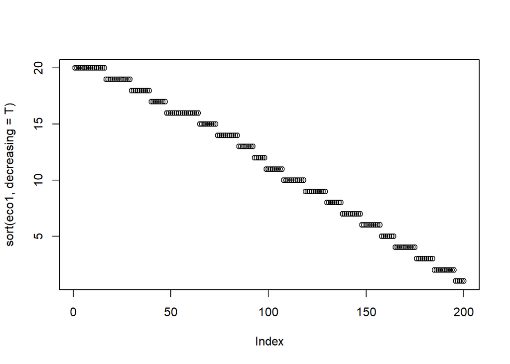

```r
#no supe ponerle las líneas sin ggplot
plot(sort(eco1,decreasing = T), type="p")
```

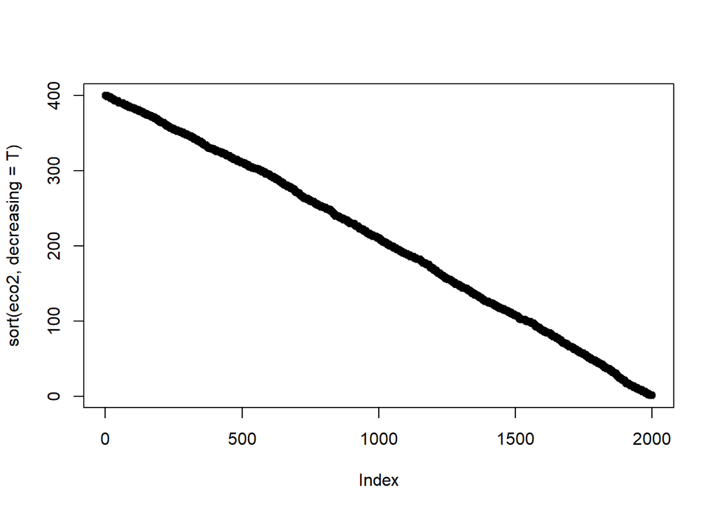

```r
plot(sort(eco2,decreasing = T), type="p")
```

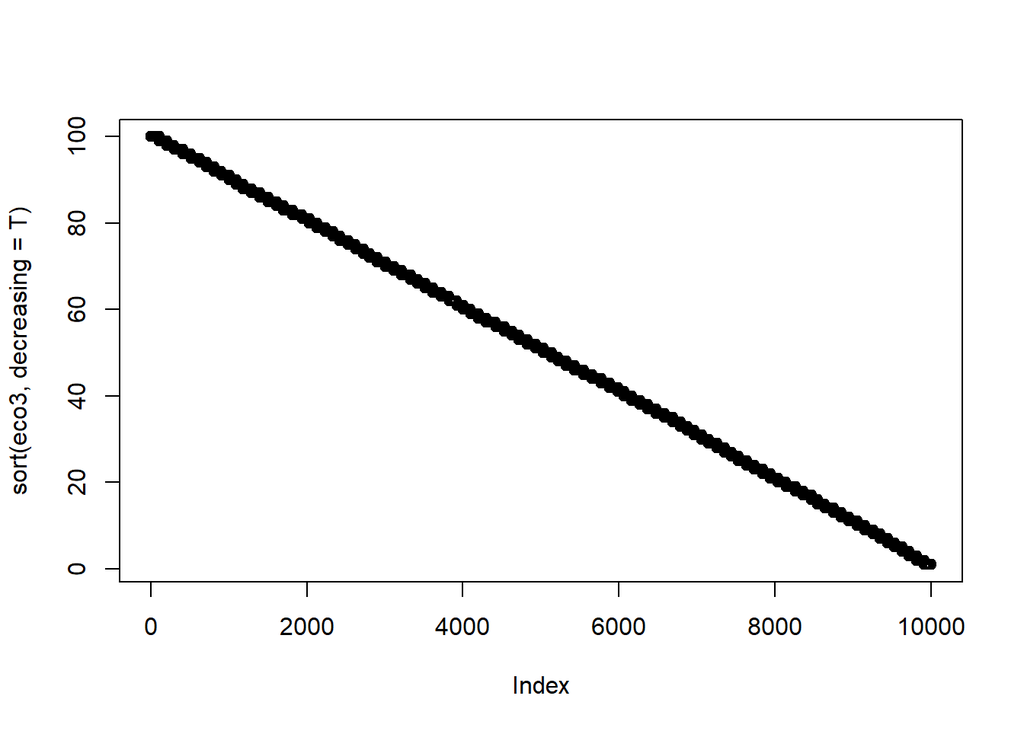

```r
plot(sort(eco3,decreasing = T), type="p")
```

# Segundo ejericio:

1. A partir de un objeto de tipo phyloseq generado de un análisis de dentificación taxónomica apartir del gen 16S ribosomal elabora un programa que 1.1 Calcule distintas medidas de diversidad 1.2 Elabore una gráfica de barras de abundancias por muestras. 1.3 Elabore un análisis de reducción de dimensionalidad 1.4 Muestre el microbioma core de las muestras 1.5 (Opcional) genere redes de co-abundacia por muestra.